# Doces de halloween

Mariana Marques dos Santos Dela Bianca

# Introdução

Esse relatório é sobre o último lab do período da disciplina de Ciência de Dados Descritiva. Foi proposto pelo professor que escolhêssemos a base de dados que gostaríamos de utilizar, então depois de dedicar um bom tempo pesquisando algo divertido e interessante encontrei algo que achasse legal: [Ranking de doces de Halloween](https://data.fivethirtyeight.com/)! Esses dados foram gerados a partir de uma pesquisa online sobre qual doce dentre os disponíveis (na pesquisa) a pessoa preferia. Você pode encontrar mais informações sobre essa pesquisa aqui: [The Ultimate Halloween Candy Power Ranking](https://fivethirtyeight.com/features/the-ultimate-halloween-candy-power-ranking/).

### Dados

```r
data = read.csv(here::here("data/candy-data.csv"))

datatable(data %>% select(competitorname, chocolate, sugarpercent, pricepercent))
```

|  | competitorname | chocolate | sugarpercent | pricepercent |
| --- | --- | --- | --- | --- |
| 1 | 100 Grand | 1 | 0.73199999 | 0.86000001 |
| 2 | 3 Musketeers | 1 | 0.60399997 | 0.51099998 |
| 3 | One dime | 0 | 0.011 | 0.116 |
| 4 | One quarter | 0 | 0.011 | 0.51099998 |
| 5 | Air Heads | 0 | 0.90600002 | 0.51099998 |
| 6 | Almond Joy | 1 | 0.465 | 0.76700002 |
| 7 | Baby Ruth | 1 | 0.60399997 | 0.76700002 |
| 8 | Boston Baked Beans | 0 | 0.31299999 | 0.51099998 |
| 9 | Candy Corn | 0 | 0.90600002 | 0.32499999 |
| 10 | Caramel Apple Pops | 0 | 0.60399997 | 0.32499999 |

[output cut: 75 more lines]

As variáveis que escolhi para realizar a regressão foram a quantidade de açúcar (sugarpercent), o preço (pricepercent) e se o doce era de chocolate ou não (chocolate). A seguir podemos visualizar a distribuição de cada variável juntamente com a chance do doce ganhar a pesquisa:

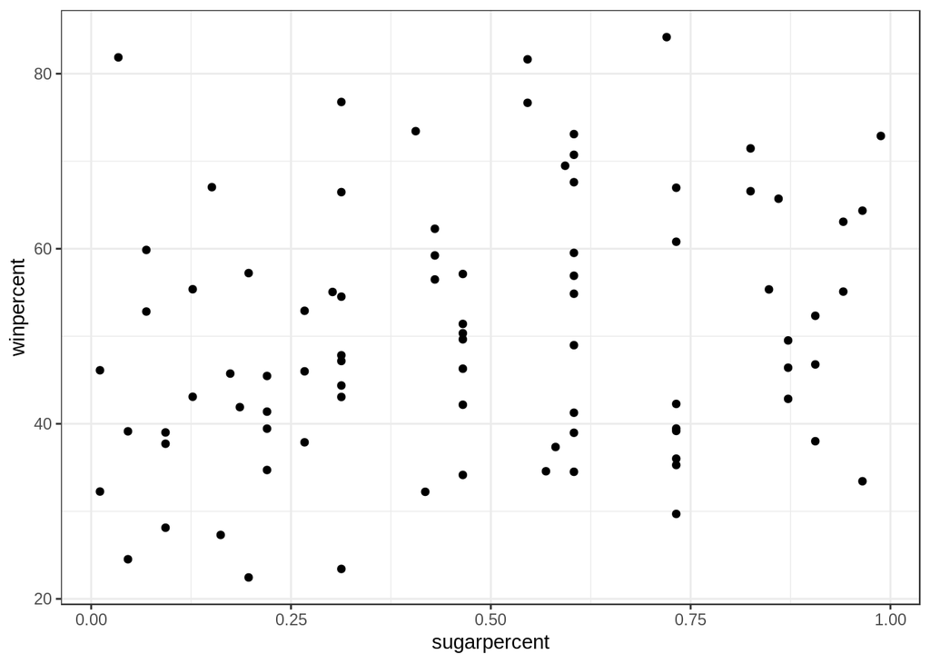

```r
data %>%
  ggplot(aes(y = winpercent, x = sugarpercent)) +
  geom_point()
```

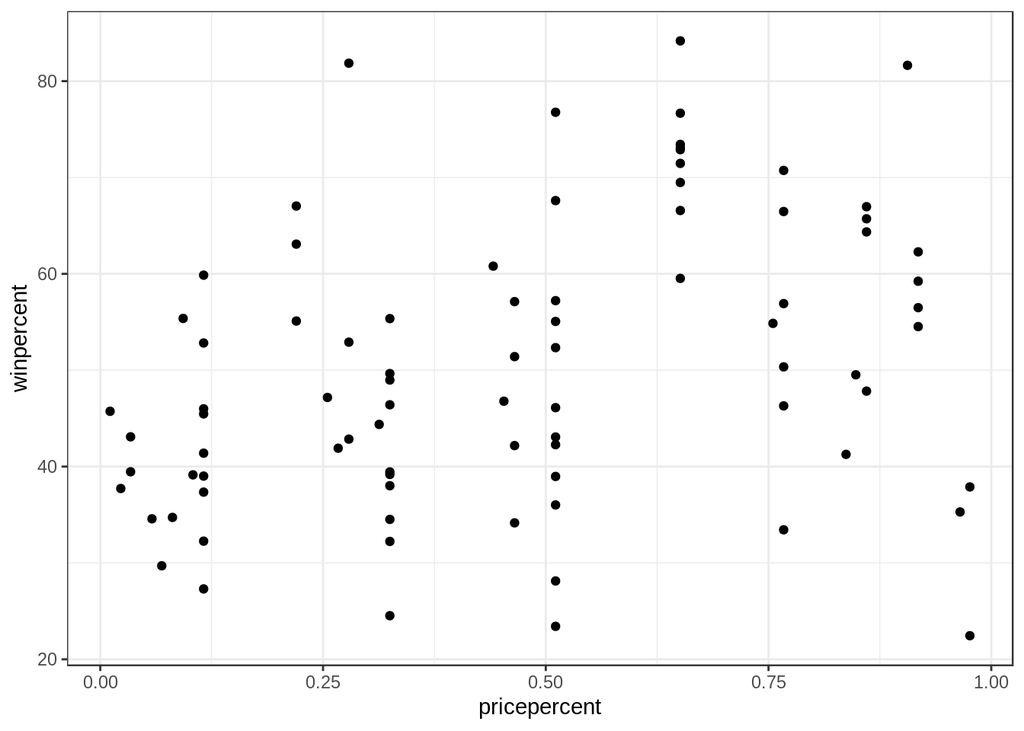

```r
data %>%
  ggplot(aes(y = winpercent, x = pricepercent)) +
  geom_point()
```

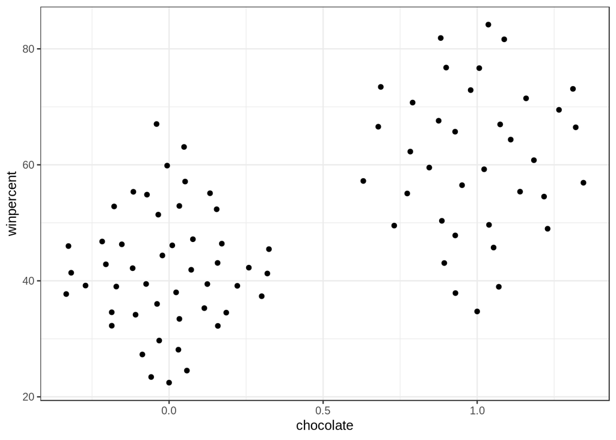

```r
data %>%
  ggplot(aes(y = winpercent, x = chocolate)) +
  geom_quasirandom()
```

Como é possível perceber, as variáveis *açúcar* e *preço* se comportam de forma linear, não precisando realizar nenhuma transformação para utilizaá-las no modelo de regressão linear a seguir.

# Modelo da regressão linear

```r
modelo1 = lm(winpercent ~ sugarpercent + pricepercent + chocolate,
             data = data)

tidy(modelo1)
```

```
## # A tibble: 4 x 5
##   term         estimate std.error statistic  p.value
##   <chr>           <dbl>     <dbl>     <dbl>    <dbl>
## 1 (Intercept)     38.6       2.81    13.8   6.50e-23
## 2 sugarpercent     9.04      4.63     1.95  5.42e- 2
## 3 pricepercent    -1.66      5.27    -0.315 7.54e- 1
## 4 chocolate       18.7       2.87     6.53  5.40e- 9
```

```r
glance(modelo1)
```

```
## # A tibble: 1 x 11
##   r.squared adj.r.squared sigma statistic  p.value    df logLik   AIC   BIC
## *     <dbl>         <dbl> <dbl>     <dbl>    <dbl> <int>  <dbl> <dbl> <dbl>
## 1     0.433         0.412  11.3      20.6 5.20e-10     4  -325.  659.  671.
## # ... with 2 more variables: deviance <dbl>, df.residual <int>
```

## Porcentagem de açúcar

```r
plotar_modelo_sugar = data %>%
  data_grid(sugarpercent = seq_range(sugarpercent, 10),
            pricepercent = mean(pricepercent),
            chocolate = c(1, 0)) %>%
  add_predictions(modelo1)

glimpse(plotar_modelo_sugar)
```

```
## Observations: 20
## Variables: 4
## $ sugarpercent <dbl> 0.0110000, 0.0110000, 0.1195556, 0.1195556, 0.228...
## $ pricepercent <dbl> 0.4688824, 0.4688824, 0.4688824, 0.4688824, 0.468...
## $ chocolate    <dbl> 0, 1, 0, 1, 0, 1, 0, 1, 0, 1, 0, 1, 0, 1, 0, 1, 0...
## $ pred         <dbl> 37.93950, 56.66527, 38.92049, 57.64626, 39.90149,...
```

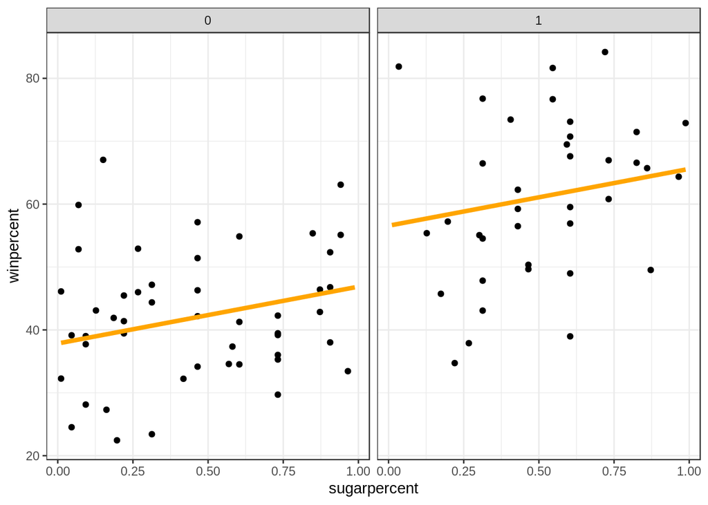

```r
ggplot(data = data, aes(x = sugarpercent)) +
  geom_point(aes(y = winpercent)) +
  geom_line(data = plotar_modelo_sugar, aes(y = pred), color = "orange", size = 1.5) +
  facet_wrap(~chocolate)
```

Podemos considerar, observando a linha de regressão, que quanto mais açúcar o doce contiver mais chance de sucesso no halloween ele terá. Mas não podemos esquecer que os dados estão bem dispersos e o resultado provavelmente não estará dentro dos padrões da linha de regressão.

## Porcentagem do preço

```r
plotar_modelo_price = data %>%
  data_grid(sugarpercent = mean(sugarpercent),
            pricepercent = seq_range(pricepercent, 10),
            chocolate = c(1, 0)) %>%
  add_predictions(modelo1)

glimpse(plotar_modelo_price)
```

```
## Observations: 20
## Variables: 4
## $ sugarpercent <dbl> 0.4786471, 0.4786471, 0.4786471, 0.4786471, 0.478...
## $ pricepercent <dbl> 0.0110000, 0.0110000, 0.1182222, 0.1182222, 0.225...
## $ chocolate    <dbl> 0, 1, 0, 1, 0, 1, 0, 1, 0, 1, 0, 1, 0, 1, 0, 1, 0...
## $ pred         <dbl> 42.92604, 61.65181, 42.74796, 61.47373, 42.56987,...
```

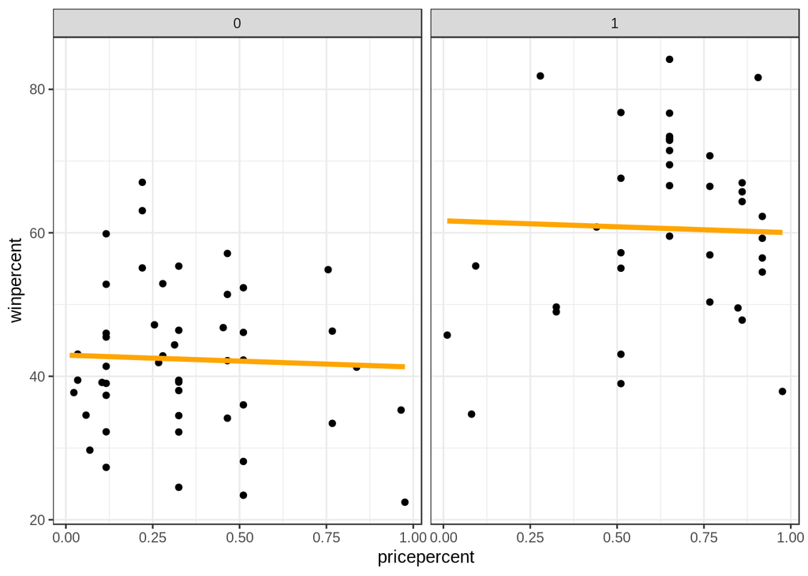

```r
ggplot(data = data, aes(x = pricepercent)) +
  geom_point(aes(y = winpercent)) +
  geom_line(data = plotar_modelo_price, aes(y = pred), color = "orange", size = 1.5) +
  facet_wrap(~chocolate)
```

Observando os gráficos sobre o preço é possível perceber que quando maior o preço menor a chance do doce fazer sucesso, pois a linha de regressão está aparentemente com uma inclinação negativa. Mas da mesma forma que os gráficos da porcentagem de açúcar mostram, os gráficos sobre o preço dos doces contém pontos muito dispersos, indicando que o resultado provavelmente não está muito próximo da linha de regressão.

## Sobre a fórmula da regressão

O formato da fórmula da regressão que fizemos é: winpercent = 38.62 + (9.03).(sugarpercent) + (-1.66).pricepercent + (18.72).(chocolate) Chocolate é uma variável categórica, portanto se o doce for de chocolate a porcentagem de ganho aumenta em 18.72%.

O modelo explica 41,16% da variância da variável da resposta (R2 = 0,43), o que é um resultado considerável, levando em consideração que usando apenas essas três variáveis (açúcar, preço e chocolate) no modelo e ele explica quase metade da variância da variável da resposta.